# How to: Weather Radials

data-visualization

highcharts

ggplot2

TLDR: Creating weather radials withh highcharter and ggplot2

Joshua Kunst http://jkunst.com/  
03-24-2016

I was surfing by the deep seas of the web and I found the *Brice Pierre de la Briere*’s [blocks](http://bl.ocks.org/bricedev) and I saw the *weather radials* which originally are a [poster collection](http://weather-radials.com/). Brice uses D3 and he used D3 very well and I love D3 but I’m in a rookie level to do something like him. **D3 is not for everybody** and surely not for me, I would love to lear more but family, work and R has priority over D3 so how can I do something like that. Well… We have R & highcharter. So let’s try.

We’ll use the same data as Brice https://www.wunderground.com/.

```
library(tidyverse)
library(highcharter)
library(lubridate)

df <- read_csv("http://bl.ocks.org/bricedev/raw/458a01917183d98dff3c/sf.csv")

glimpse(df)
```

```
Rows: 365
Columns: 23
$ date                         <chr> "2014-1-1", "2014-1-2", "201...
$ `Max TemperatureC`           <dbl> 13, 17, 18, 19, 19, 16, 16, ...
$ `Mean TemperatureC`          <dbl> 9, 12, 12, 13, 13, 11, 12, 1...
$ `Min TemperatureC`           <dbl> 5, 6, 7, 6, 7, 7, 8, 11, 11,...
$ `Dew PointC`                 <dbl> 7, 7, 8, 8, 3, 7, 11, 11, 10...
$ `MeanDew PointC`             <dbl> 4, 4, 5, 6, 0, 4, 7, 9, 8, 8...
$ `Min DewpointC`              <dbl> 2, 1, 1, 1, -3, 0, 4, 8, 6, ...
$ `Max Humidity`               <dbl> 83, 80, 80, 93, 65, 71, 86, ...
$ `Mean Humidity`              <dbl> 69, 58, 59, 65, 45, 61, 70, ...
$ `Min Humidity`               <dbl> 55, 36, 37, 36, 24, 51, 53, ...
$ `Max Sea Level PressurehPa`  <dbl> 1023, 1022, 1019, 1019, 1023...
$ `Mean Sea Level PressurehPa` <dbl> 1022, 1020, 1016, 1016, 1021...
$ `Min Sea Level PressurehPa`  <dbl> 1020, 1018, 1014, 1015, 1019...
$ `Max VisibilityKm`           <dbl> 16, 16, 16, 16, 16, 16, 16, ...
$ `Mean VisibilityKm`          <dbl> 15, 16, 16, 9, 16, 15, 14, 1...
$ `Min VisibilitykM`           <dbl> 11, 16, 14, 0, 16, 11, 11, 5...
$ `Max Wind SpeedKm/h`         <dbl> 14, 10, 23, 24, 23, 14, 24, ...
$ `Mean Wind SpeedKm/h`        <dbl> 1, 2, 6, 4, 8, 4, 7, 15, 19,...
$ `Max Gust SpeedKm/h`         <dbl> 16, 10, 26, 29, 24, 16, 27, ...
$ Precipitationmm              <chr> "0.00", "0.00", "0.00", "0.0...
$ CloudCover                   <dbl> 3, 3, 3, 2, 0, 5, 5, 7, 5, 4...
$ Events                       <chr> NA, NA, NA, "Fog", NA, NA, "...
$ WindDirDegrees               <dbl> 290, 146, 297, 266, 125, 75,...
```

```
df <- df %>%
  rename_all(str_to_lower) %>%
  rename_all(str_replace, "\\s+", "_") %>%
  mutate(
    id = seq(nrow(df)),
    date2 = as.Date(ymd(date)),
    tmstmp = datetime_to_timestamp(date2),
    month = month(ymd(date))
  )

dsmax <- df %>%
  select(tmstmp, max_temperaturec)

dsmin <- df %>%
  select(tmstmp, min_temperaturec)
```

## First try

Here we test and chart the data in the most simple way. A line time.

```
highchart() %>%
  hc_chart(type = "line") %>%
  hc_xAxis(
    type = "datetime",
    tickInterval = 30 * 24 * 3600 * 1000,
    labels = list(format = "{value: %b}")
  ) %>%
  hc_yAxis(min = 0,
           labels = list(format = "{value} C")) %>%
  hc_add_series(dsmax,
                type = "line",
                hcaes(tmstmp, max_temperaturec),
                name = "max") %>%
  hc_add_series(dsmin,
                type = "line",
                hcaes(tmstmp, min_temperaturec),
                name = "min")
```

[interactive chart not shown]

Everything seems fine. We now a little bit about the data

## To polar coordinates and columnrange!

Now, we need to change to polar cordinates to get the “radial” part, this is get using the `polar = TRUE` argument in the `hc_chart` function. Then add the data in the `columnrange` type.

[output not shown]

[interactive chart not shown]

Yay :D! A beautiful chart same as the d3 version and only using R. So sweet! I’m happy with the result. This is not a standar chart but is a king of *artistic*. What do you think? Any other examples to test this type of chart?

## Bonus Track: ggplot2 version

It’s *really really* easy to do this type of chart in ggplot2 using `geom_linerange` and `geom_polar`:

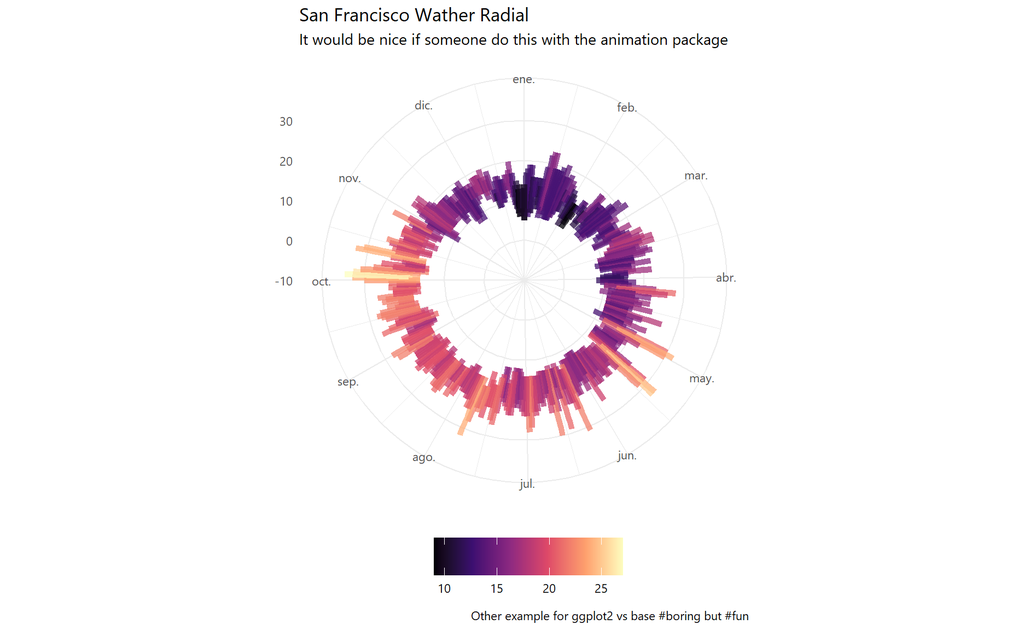

```
library(scales)

ggplot(
  df,
  aes(
    date2,
    ymin = min_temperaturec,
    ymax = max_temperaturec,
    color = mean_temperaturec
  )
) +
  geom_linerange(size = 1.3, alpha = 0.75) +
  scale_color_viridis_c(NULL, option = "A") +
  scale_x_date(labels = date_format("%b"), breaks = date_breaks("month")) +
  ylim(-10, 35) +
  labs(
    title = "San Francisco Wather Radial",
    subtitle = "It would be nice if someone do this with the animation package",
    caption = "Other example for ggplot2 vs base #boring but #fun",
    x = NULL,
    y = NULL
  ) +
  coord_polar() +
  theme(legend.position = "bottom")
```

Nice!

Searching I found someone do [this](https://www.quora.com/R-programming-language/What-is-the-most-elegant-plot-you-have-made-using-ggplot2):

> Always exist someone who did what you did before you.

[figure not shown]